# Cell Cycle and Gamma-H2AX Measurements in Atypical Teratoid Rhabdoid Tumor

Eric Prince

11/13/2017

Experimental Details

| Author | ExperimentDate | Description | Samples | Replicates | Notes |
| --- | --- | --- | --- | --- | --- |
| Irina Alimova | 2017 Nov 10 | An investigation of Cell Cycle status in 737 AT/RT cells, with a simultaneous analysis of the apoptotic marker Gamma-H2AX | No Stain [Flow Control], No Treatment, Treatment | 5 | 24 Hour Treatment |

Raw Data Values

| File | G0G1 | S | G2M | H2AX.TOTAL | H2AX.G0G1 | H2AX.S | H2AX.G2M | COUNTALL |
| --- | --- | --- | --- | --- | --- | --- | --- | --- |
| 0_NoStain_1 | 0.0000 | 0.0000 | 0.0000 | 0.0000 | NaN | NaN | NaN | 5000.0000 |
| 0_NoStain_2 | 0.0000 | 0.0000 | 0.0000 | 0.0000 | NaN | NaN | NaN | 5000.0000 |
| 0_NoStain_3 | 0.0000 | 0.0000 | 0.0000 | 0.0000 | NaN | NaN | NaN | 5000.0000 |
| 0_NoStain_4 | 0.0000 | 0.0000 | 0.0000 | 0.0000 | NaN | NaN | NaN | 5000.0000 |
| 0_NoStain_5 | 0.0000 | 0.0000 | 0.0000 | 0.0000 | NaN | NaN | NaN | 5000.0000 |
| 1_Control_1 | 59.2774 | 13.1758 | 13.7191 | 3.1785 | 1.9707 | 2.2680 | 7.7228 | 5000.0000 |
| 1_Control_2 | 59.0006 | 12.6726 | 13.8597 | 3.0094 | 1.6378 | 2.1786 | 6.1753 | 5000.0000 |
| 1_Control_3 | 61.1517 | 11.5437 | 12.4899 | 3.0819 | 1.6799 | 1.8735 | 9.0909 | 5000.0000 |
| 1_Control_4 | 59.9893 | 14.1560 | 12.5801 | 3.6325 | 2.0926 | 3.7736 | 9.1295 | 5000.0000 |
| 1_Control_5 | 61.0262 | 12.1998 | 12.5819 | 3.5207 | 1.9231 | 3.1320 | 9.5445 | 5000.0000 |
| 2_Treatment_1 | 59.2230 | 9.9281 | 10.7338 | 1.0072 | 0.6317 | 0.5797 | 2.1448 | 5000.0000 |
| 2_Treatment_2 | 59.1474 | 10.2131 | 11.9005 | 0.9769 | 0.3003 | 1.1594 | 4.2289 | 5000.0000 |
| 2_Treatment_3 | 57.2408 | 11.2336 | 12.9917 | 0.8343 | 0.1562 | 2.3873 | 2.9817 | 5000.0000 |
| 2_Treatment_4 | 58.9165 | 10.4246 | 12.1523 | 0.7321 | 0.4970 | 0.2809 | 2.6506 | 5000.0000 |
| 2_Treatment_5 | 57.7817 | 11.1209 | 13.2686 | 0.8238 | 0.4582 | 0.7937 | 2.2173 | 5000.0000 |

As we can see in the raw values, the No Stain Control had 0% event counts within any of the gating parameters. This validates that the measured signals in the Control and Treatment samples are not due to artifact and can be considered reliable. Next, we need clean the data. This will be accomplished by dropping the No Stain Control samples and COUNTALL column, then normalizing the cell cycle percentages to set each sample to a relative “100% in cycle” value. Next, the H2AX values will be normalized to the mean Control values.

Cleaned Experimental Data

| SampleNumber | Treatment | Replicate | G0G1 | S | G2M | H2AX.TOTAL | H2AX.G0G1 | H2AX.S | H2AX.G2M |
| --- | --- | --- | --- | --- | --- | --- | --- | --- | --- |
| 1 | Control | 1 | 68.78939 | 15.29006 | 15.92055 | 0.9676977 | 1.0590492 | 0.8574215 | 0.9268176 |
| 1 | Control | 2 | 68.98001 | 14.81605 | 16.20394 | 0.9162151 | 0.8801496 | 0.8236237 | 0.7411012 |
| 1 | Control | 3 | 71.78668 | 13.55128 | 14.66204 | 0.9382878 | 0.9027740 | 0.7082801 | 1.0910040 |
| 1 | Control | 4 | 69.17155 | 16.32278 | 14.50567 | 1.1059185 | 1.1245580 | 1.4266164 | 1.0956364 |
| 1 | Control | 5 | 71.11956 | 14.21757 | 14.66287 | 1.0718809 | 1.0334691 | 1.1840583 | 1.1454408 |
| 2 | Treatment | 1 | 74.13541 | 12.42801 | 13.43658 | 0.3066431 | 0.3394740 | 0.2191566 | 0.2573987 |
| 2 | Treatment | 2 | 72.78695 | 12.56827 | 14.64479 | 0.2974183 | 0.1613805 | 0.4383133 | 0.5075127 |
| 2 | Treatment | 3 | 70.26334 | 13.78929 | 15.94737 | 0.2540035 | 0.0839415 | 0.9025231 | 0.3578355 |
| 2 | Treatment | 4 | 72.29604 | 12.79196 | 14.91201 | 0.2228886 | 0.2670866 | 0.1061948 | 0.3181000 |
| 2 | Treatment | 5 | 70.31868 | 13.53382 | 16.14751 | 0.2508068 | 0.2462355 | 0.3000597 | 0.2660994 |

Now, we can summarize the data.

Data Summary

| Measurement | SampleNumber | Treatment | G0G1 | S | G2M | H2AX.TOTAL | H2AX.G0G1 | H2AX.S | H2AX.G2M |
| --- | --- | --- | --- | --- | --- | --- | --- | --- | --- |
| Mean Value | 1 | Control | 69.969437 | 14.8395511 | 15.1910122 | 1.0000000 | 1.0000000 | 1.0000000 | 1.0000000 |
| Mean Value | 2 | Treatment | 71.960082 | 13.0222682 | 15.0176500 | 0.2663521 | 0.2196236 | 0.3932495 | 0.3413892 |
| Standard Deviation | 1 | Control | 1.381419 | 1.0547501 | 0.8041589 | 0.0840496 | 0.1048078 | 0.2968235 | 0.1665573 |
| Standard Deviation | 2 | Treatment | 1.665968 | 0.6046319 | 1.0944084 | 0.0348987 | 0.0989027 | 0.3093475 | 0.1014062 |

Lastly, we will plot the data. The first graph to look at is the Cell Cycle results.

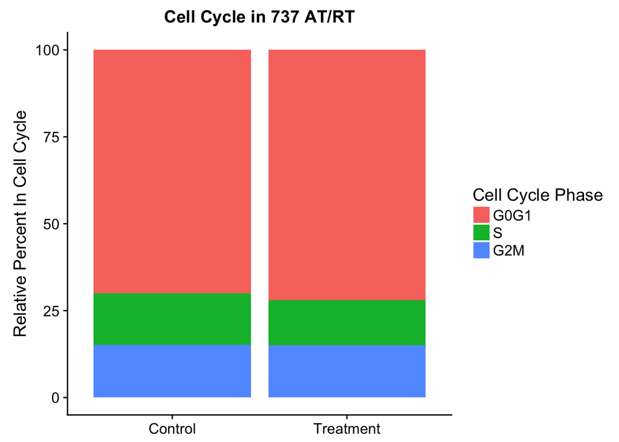

Next we will look at the total H2AX expression data.

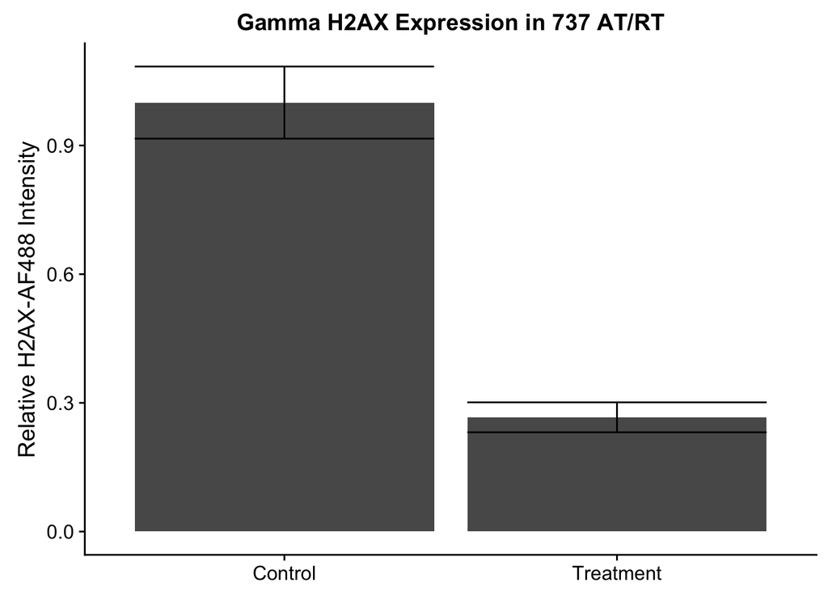

At first glance, it appears that the treatment samples have significantly less h2ax expression. However, the actual raw H2AX-AF488 intensity values for control samples is roughly 3%, and for treatment samples it is roughly 1%. So neither value is truly very high at all. I think that is safe to say that they are more-or-less equivalent in H2AX-AF488 values.

Lastly, we will subdivide the H2AX assay by cell cycle phase.

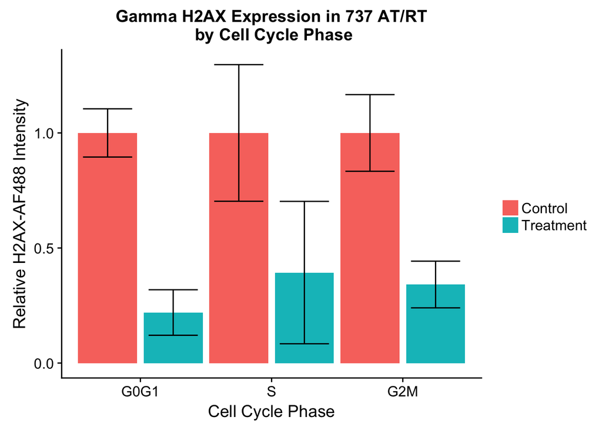

Here we see the same trends that were observed in the total H2AX plot. Again, I would not consider these values to be significant due to the raw value levels as discussed above.